# W3cubDocs

### Linking your npm and GitHub accounts

1. On the account settings page, you will find a button to link your GitHub account. Click that.

[figure not shown]

2. If you are not currently logged in to GitHub you will be prompted to go through the authentication flow.

[figure not shown]

3. After successfully logging in, or if you already had an active browser sessions, you will be prompted to "authorize npm account link", click the button.

[figure not shown]

4. You will be redirected to npm and the link will show as successful in your settings.

[figure not shown]

### Linking your npm and Twitter accounts

1. On the account settings page, you will find a button to link your Twitter account. Click that.

[figure not shown]

2. If you are not currently logged in to Twitter you will be prompted to go through the authentication flow. Click "Log in"

[figure not shown]

3. After successfully logging in, or if you already had an active browser sessions, you will be prompted to "Authorize app", click the button.

[figure not shown]

4. You will be redirected to npm and the link will show as successful in your settings.

[figure not shown]

### Disconnecting your GitHub account from npm

1. On the account settings page, you will find a button to disconnect your GitHub account. Click that.

[figure not shown]

   *Note: Clicking disconnect will only disconnect the link from your npm account. You need to `revoke` permissions from your [GitHub app authorization settings](https://github.com/settings/apps/authorizations) to permanently remove the integration from your GitHub account*

### Disconnecting your Twitter account from npm

[figure not shown]

   *Note: Clicking disconnect will only disconnect the link from your npm account. You need to `revoke` permissions from your [Twitter connect apps management page](https://twitter.com/settings/connected_apps) to permanently remove the integration from your Twitter account*

## Managing user account profile settings from the command line

**Note:** Your npm client must be version 5.5.1 or higher to change your account settings from the CLI. To update to the latest version of npm, on the command line, run `npm install npm@latest -g`

### Viewing user account profile settings from the command line

To view your user profile settings from the CLI, on the command line, run the following command:

```
npm profile get
```

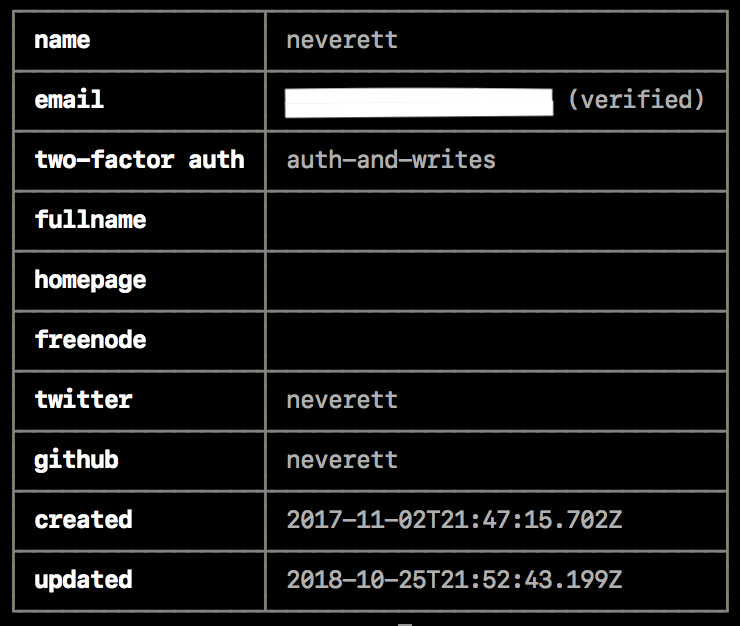

### Updating user account profile settings from the command line

From the CLI, you can change the following properties for your user account:

- `email`
- `two-factor auth`
- `fullname`
- `homepage`
- `freenode`
- `password`
1. On the command line, type the following command, replacing `property` with the name of the property, and `value` with the new value:

   ```
   npm profile set <prop> <value>
   ```

2. When prompted, provide your current password.
3. If you have enabled two-factor authentication on your account, when prompted, enter a one-time password.

For more details, see the `profile` [command line documentation](https://docs.npmjs.com/cli/v8/commands/npm-profile/).

#### Setting a password from the command line

1. On the command line, type the following command:

   ```
   npm profile set password
   ```

2. When prompted, provide your current password.
3. When prompted, type a new password.

To protect your account, when you reset your password from the command line, it must:

- be longer than 10 characters
- not contain part of your username
- not be in the "[Have I Been Pwned](https://haveibeenpwned.com/)" breach database

#### Configuring two-factor authentication from the command line

Enabling two-factor authentication on your account helps protect against unauthorized access to your account and packages.

To enable, configure, and disable two-factor authentication from the command line, see "Configuring two-factor authentication".

[Edit this page on GitHub](https://github.com/npm/documentation/edit/main/content/getting-started/managing-your-npm-user-account/managing-your-profile-settings.mdx)

© npm, Inc. and Contributors  
Licensed under the npm License.  
npm is a trademark of npm, Inc.  
https://docs.npmjs.com/managing-your-profile-settings